# HT-1-Analisis-Exploratorio

Juan De Leon, Maria Jose Castro, Jose Block

2/8/2021

## Ejercicios

1. Haga una exploración rápida de sus datos, para eso haga un resumen de su conjunto de datos.

```
##        id           imdb_id            popularity           budget
##  Min.   :     5   Length:10866       Min.   : 0.00006   Min.   :        0
##  1st Qu.: 10596   Class :character   1st Qu.: 0.20758   1st Qu.:        0
##  Median : 20669   Mode  :character   Median : 0.38386   Median :        0
##  Mean   : 66064                      Mean   : 0.64644   Mean   : 14625701
##  3rd Qu.: 75610                      3rd Qu.: 0.71382   3rd Qu.: 15000000
##  Max.   :417859                      Max.   :32.98576   Max.   :425000000
##     revenue          original_title         cast             homepage
##  Min.   :0.000e+00   Length:10866       Length:10866       Length:10866
##  1st Qu.:0.000e+00   Class :character   Class :character   Class :character
##  Median :0.000e+00   Mode  :character   Mode  :character   Mode  :character
##  Mean   :3.982e+07
##  3rd Qu.:2.400e+07
##  Max.   :2.782e+09
##    director           tagline            keywords           overview
##  Length:10866       Length:10866       Length:10866       Length:10866
##  Class :character   Class :character   Class :character   Class :character
##  Mode  :character   Mode  :character   Mode  :character   Mode  :character
##
##
##
##     runtime         genres          production_companies release_date
##  Min.   :  0.0   Length:10866       Length:10866         Length:10866
##  1st Qu.: 90.0   Class :character   Class :character     Class :character
##  Median : 99.0   Mode  :character   Mode  :character     Mode  :character
##  Mean   :102.1
##  3rd Qu.:111.0
##  Max.   :900.0
##    vote_count      vote_average    release_year    budget_adj
##  Min.   :  10.0   Min.   :1.500   Min.   :1960   Min.   :        0
##  1st Qu.:  17.0   1st Qu.:5.400   1st Qu.:1995   1st Qu.:        0
##  Median :  38.0   Median :6.000   Median :2006   Median :        0
##  Mean   : 217.4   Mean   :5.975   Mean   :2001   Mean   : 17551040
##  3rd Qu.: 145.8   3rd Qu.:6.600   3rd Qu.:2011   3rd Qu.: 20853251
##  Max.   :9767.0   Max.   :9.200   Max.   :2015   Max.   :425000000
##   revenue_adj
##  Min.   :0.000e+00
##  1st Qu.:0.000e+00
##  Median :0.000e+00
##  Mean   :5.136e+07
##  3rd Qu.:3.370e+07
##  Max.   :2.827e+09
```

2. Diga el tipo de cada una de las variables (cualitativa ordinal o nominal, cuantitativa continua, cuantitativa discreta).

```
##                Variable      Tipo.de.Variable
## 1                    id                   N/A
## 2               imdb_id                   N/A
## 3            popularity Cuantitativa Continua
## 4                budget Cuantitativa Discreta
## 5               revenue Cuantitativa Discreta
## 6        original_title   Cualitativa Nominal
## 7                  cast   Cualitativa Nominal
## 8              homepage   Cualitativa Nominal
## 9              director   Cualitativa Nominal
## 10              tagline   Cualitativa Nominal
## 11             keywords   Cualitativa Nominal
## 12             overview   Cualitativa Nominal
## 13              runtime Cuantitativa Discreta
## 14               genres   Cualitativa Nominal
## 15 production_companies   Cualitativa Nominal
## 16         release_date Cuantitativa Discreta
## 17           vote_count Cuantitativa Discreta
## 18         vote_average Cuantitativa Continua
## 19         release_year Cuantitativa Discreta
## 20           budget_adj Cuantitativa Continua
## 21          revenue_adj Cuantitativa Continua
```

3. Investigue si las variables cuantitativas siguen una distribución normal y haga una tabla de frecuencias de las variables cualitativas. Explique todos los resultados.

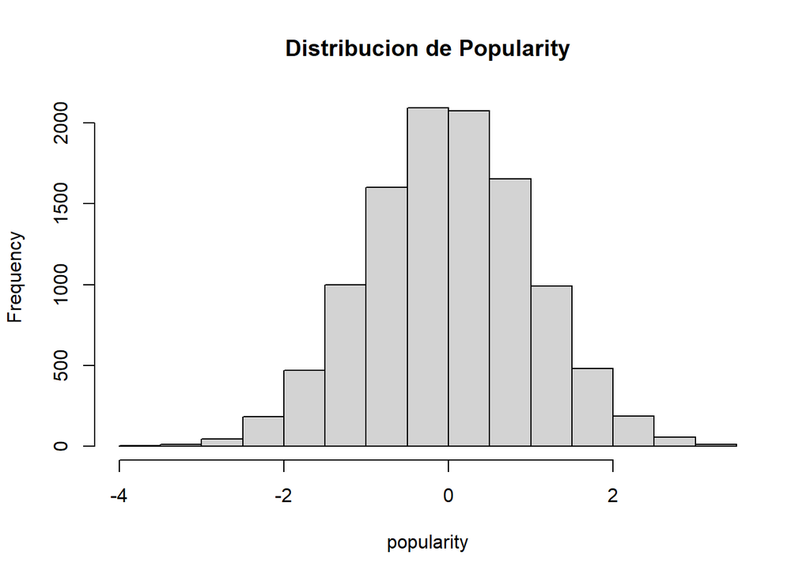

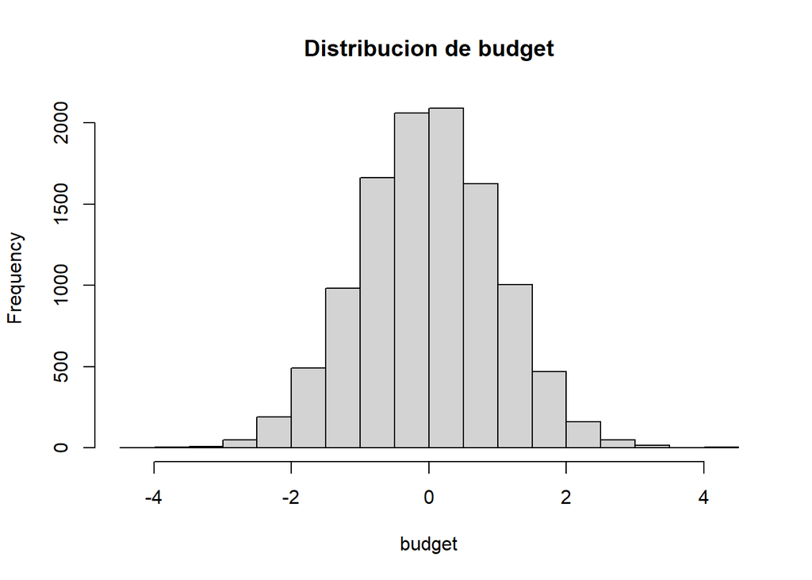

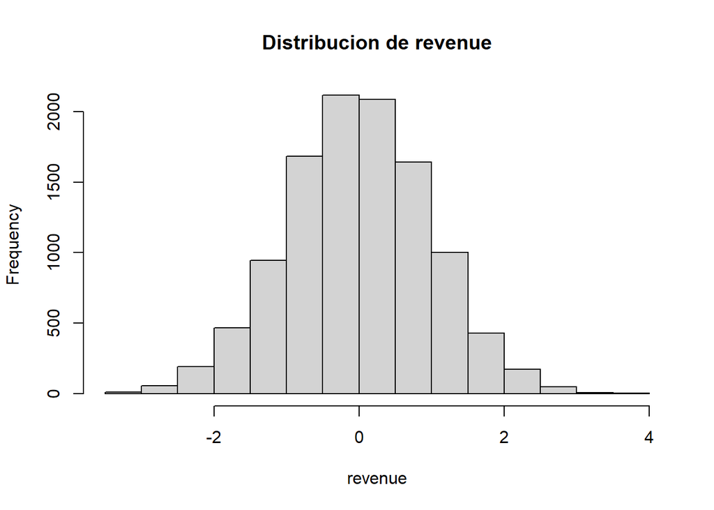

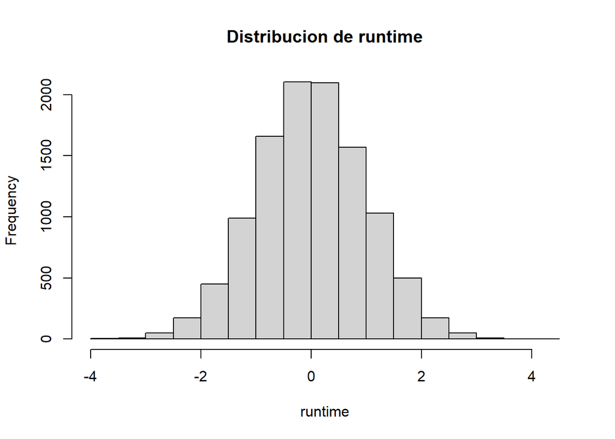

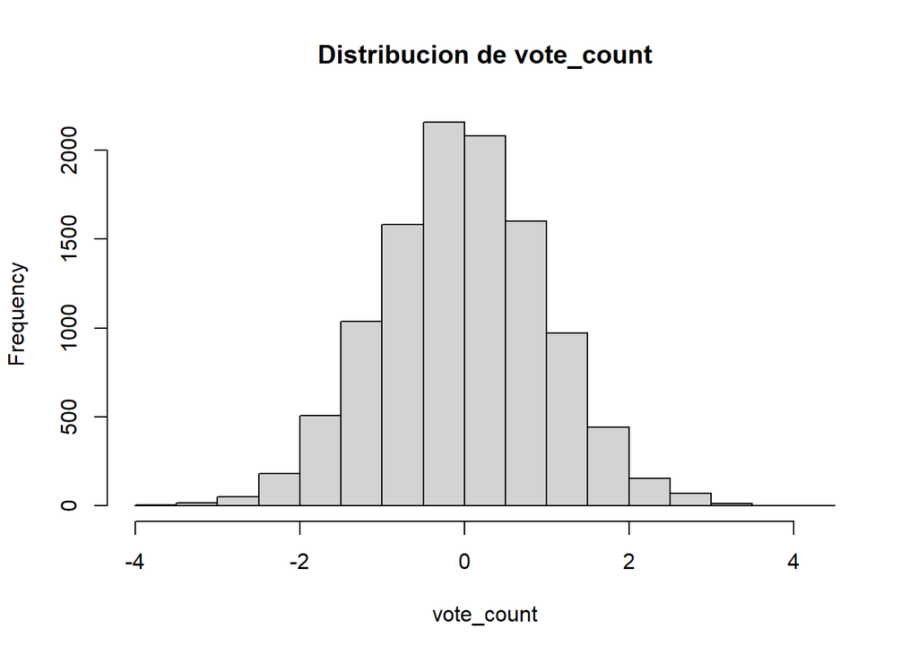

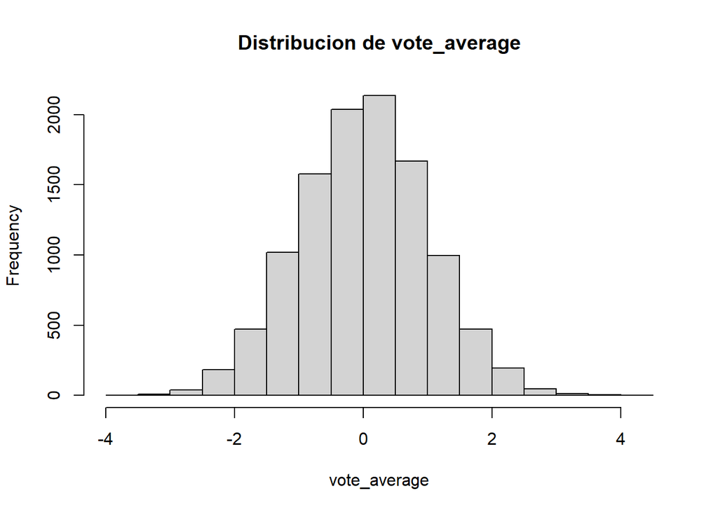

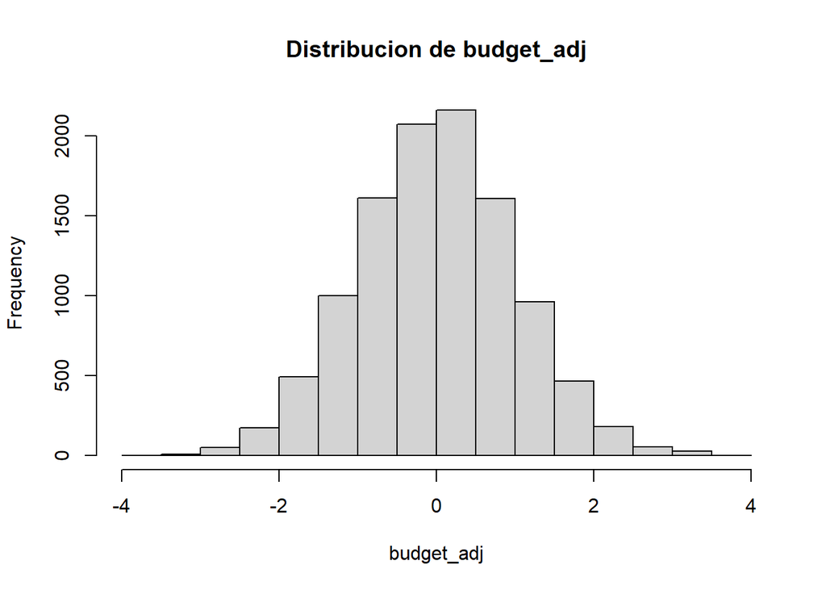

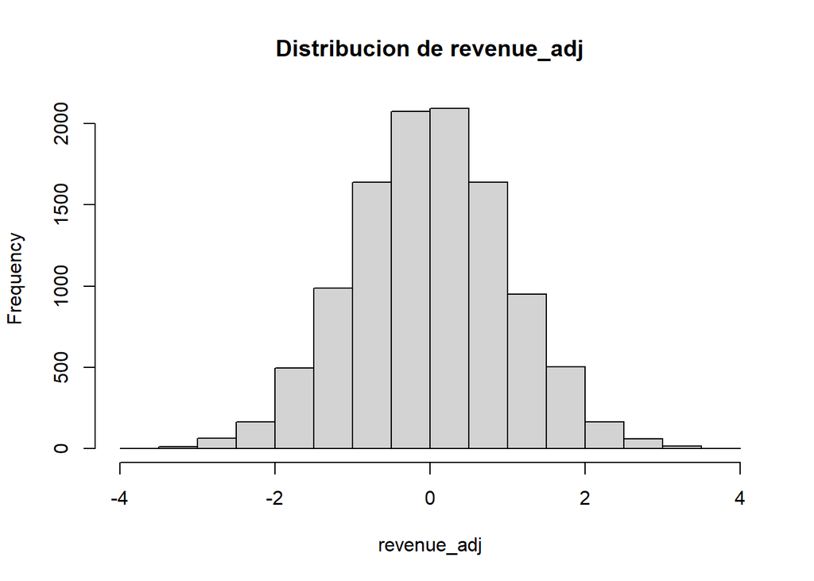

- Debido a que las tablas de frecuencia son muy grandes dejamos indicado como se obentrian todas las tablas de frecuencia de las variables cualitativas.

```
table(dataframe$original_title)
table(dataframe$cast)
table(dataframe$homepage)
table(dataframe$director)
table(dataframe$tagline)
table(dataframe$keywords)
table(dataframe$overview)
table(dataframe$genreS)
table(dataframe$production_companies)
```

4. Responda las siguientes preguntas:
   - ¿Cuáles son las 10 películas que contaron con más presupuesto?

   ```
   ##          id                              original_title    budget
   ## 2245  46528                           The Warrior's Way 425000000
   ## 3376   1865 Pirates of the Caribbean: On Stranger Tides 380000000
   ## 7388    285    Pirates of the Caribbean: At World's End 300000000
   ## 15    99861                     Avengers: Age of Ultron 280000000
   ## 6571   1452                            Superman Returns 270000000
   ## 1930  38757                                     Tangled 260000000
   ## 4412  49529                                 John Carter 260000000
   ## 7395    559                                Spider-Man 3 258000000
   ## 5509  57201                             The Lone Ranger 255000000
   ## 635  122917   The Hobbit: The Battle of the Five Armies 250000000
   ```

   - ¿Cuáles son las 10 películas que más ingresos tuvieron?

   ```
   ##          id                               original_title    revenue
   ## 1387  19995                                       Avatar 2781505847
   ## 4    140607                 Star Wars: The Force Awakens 2068178225
   ## 5232    597                                      Titanic 1845034188
   ## 4362  24428                                 The Avengers 1519557910
   ## 1    135397                               Jurassic World 1513528810
   ## 5    168259                                    Furious 7 1506249360
   ## 15    99861                      Avengers: Age of Ultron 1405035767
   ## 3375  12445 Harry Potter and the Deathly Hallows: Part 2 1327817822
   ## 5423 109445                                       Frozen 1274219009
   ## 5426  68721                                   Iron Man 3 1215439994
   ```

   - ¿Cuál es la película que más votos tuvo?

   ```
   ##         id original_title vote_count
   ## 1920 27205      Inception       9767
   ```

   - ¿Cuál es la peor película de acuerdo a los votos de todos los usuarios?

   ```
   ##          id           original_title vote_average
   ## 7773  25055            Transmorphers          1.5
   ## 10866 22293 Manos: The Hands of Fate          1.5
   ```

   - ¿Cuántas películas se hicieron en cada año? ¿En qué año se hicieron más películas? Haga un gráfico de barras

   ```
   ##    release_year   n
   ## 1          1960  32
   ## 2          1961  31
   ## 3          1962  32
   ## 4          1963  34
   ## 5          1964  42
   ## 6          1965  35
   ## 7          1966  46
   ## 8          1967  40
   ## 9          1968  39
   ## 10         1969  31
   ## 11         1970  41
   ## 12         1971  55
   ## 13         1972  40
   ## 14         1973  55
   ```

   [output cut: 42 more lines]

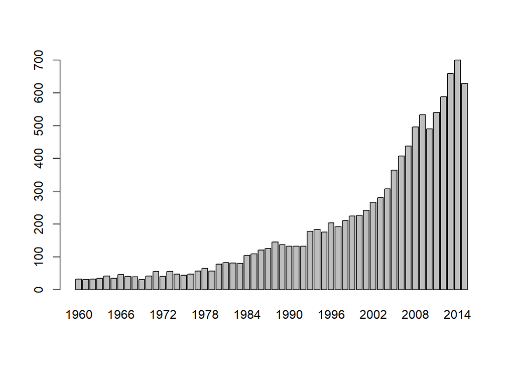

   ```
   ##    release_year   n
   ## 55         2014 700
   ```

   - ¿Cuál es el género principal de las 20 películas más populares? -Para esto se separo la lista de los generos y solo se tomo en cuenta el primero de la lista.

```
##
##          Action       Adventure           Drama Science Fiction         Western
##               9               6               2               2               1
```

```
- ¿Cuál es el género que predomina en el conjunto de datos? Represéntelo usando un gráfico
- En este cao el genero mass comun es las peliculas de drama. Se separaron por genero.
```

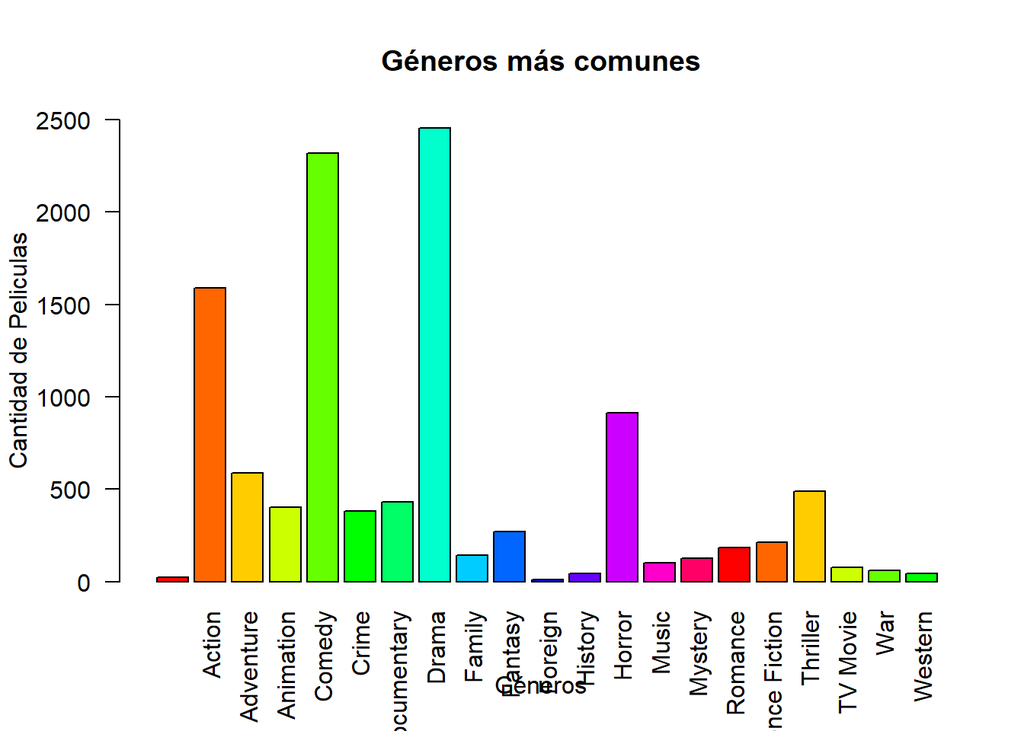

```
- ¿Las películas de qué genero principal obtuvieron mayores ganancias?
- Las peliculas de Aventura son las que mas ganacias dan a los estudias, para poder hacer esto se separaron los generos de cada pelicula. Luego se creo el promedio de gancias por genero y se grafico.
```

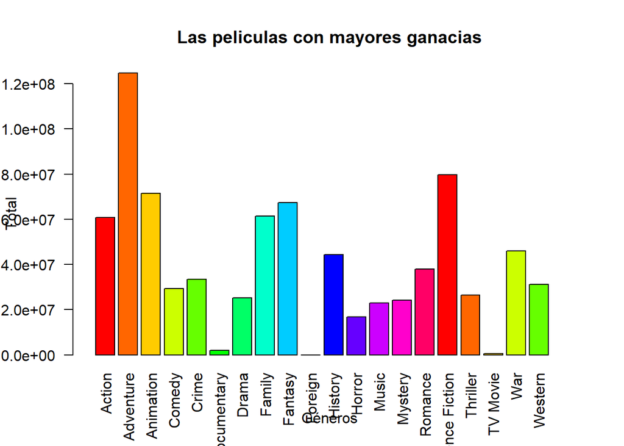

```
- ¿Las películas de qué genero principal necesitaron mayor presupuesto?
```

- Las peliculas de Aventura son las que mas presupuesto requieren, para poder hacer esto se separaron los generos de cada pelicula. Luego se creo el promedio re presupuesto por genero y se grafico.

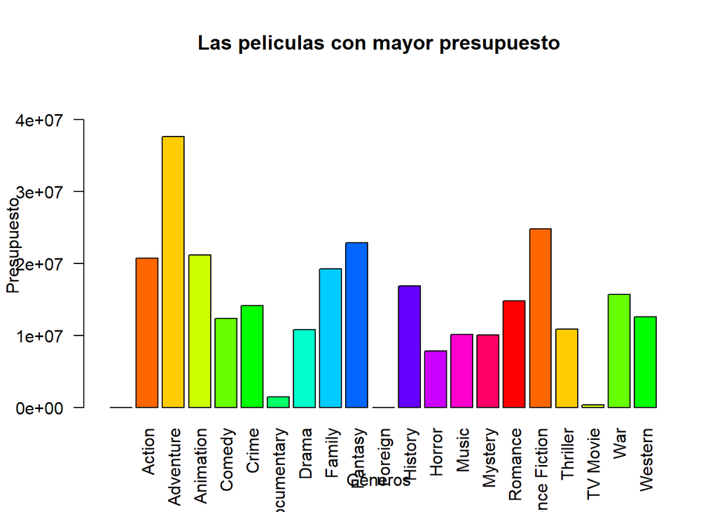

  - ¿Quiénes son los 20 mejores directores que hicieron películas altamente calificadas?

```
##
##                                                            Andrew Jarecki
##                                    4                                    1
##                      Anthony Mandler                        Carl Tibbetts
##                                    1                                    1
##                          Curt Morgan                         David Mallet
##                                    1                                    1
##                     Derek Frankowski                       Frank Darabont
##                                    1                                    1
##                          James Payne               Jennifer Siebel Newsom
##                                    1                                    1
##                       Jonathan Demme           Jorge RamÃƒÂrez SuÃƒÂ¡rez
##                                    1                                    1
##                         Mark Cousins Martin Scorsese|Michael Henry Wilson
##                                    1                                    1
##               Sam Dunn|Scot McFadyen                         Saul Swimmer
##                                    1                                    1
##                          Stan Lathan
##                                    1
```

```
- ¿Cómo se correlacionan los presupuestos con los ingresos? ¿Los altos presupuestos significan altos ingresos? Haga los gráficos que necesite, histograma, diagrama de dispersión
```

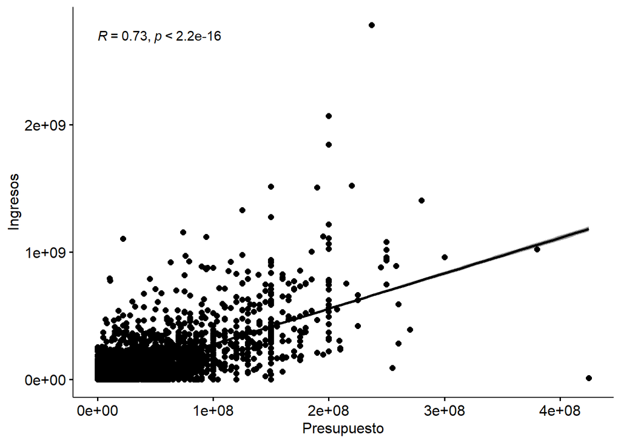

A pesar de que la correlacion sea de 0.73, por la forma en la que el grafico de dispersion se exparse, resulta dificil concluir. Pero nuestra conclusion es no, hay lanzamientos con muy poco presupuesto, pero con un alto ingreso comparado con el presupuesto. Tambien hay otros que cuentan con un presupuesto monstruoso pero con un ingreso en casi 0. Depende mucho de la tematica de la pelicula. Consideramos que es cuestion de habilidad sobre presupuesto.

```
- ¿Se asocian ciertos meses de lanzamiento con mejores ingresos?
```

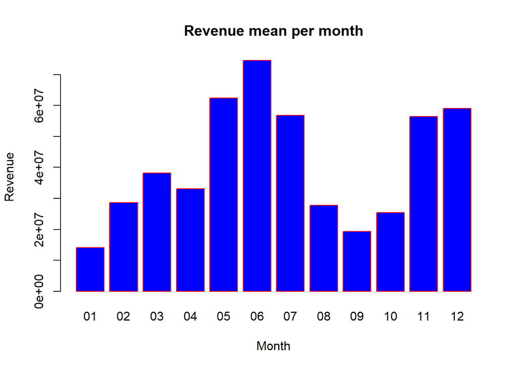

Segun el grafico de la media de ingresos por mes el mes con mayor ingresos es junio seguido de mayo. Es importante saber que un dato atipico extremo puede cambiar la media de un mes sustancialmente. - ¿En qué meses se han visto los lanzamientos máximos?

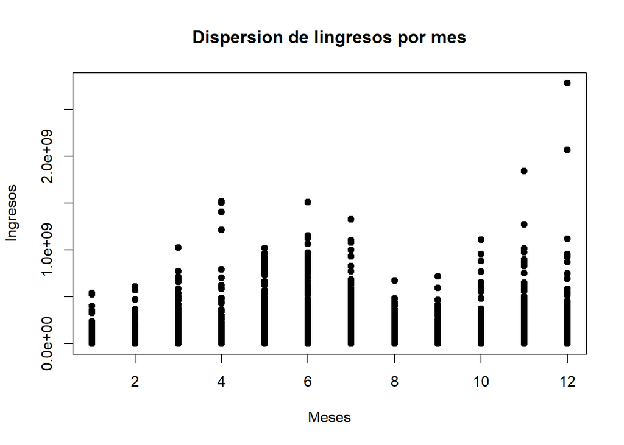

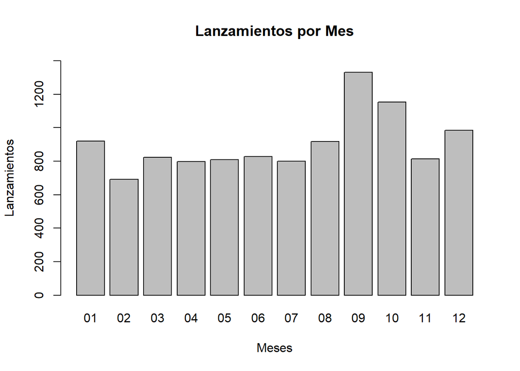

En la primer grafico de dispercion podemos notar los datos atipicos extremos por cada mes. Esto nos da una idea de como se ve afectada la media de ingresos por mes. Se puede ver que el dato mas alto esta en diciembre, se trata de Avatar.

```
- ¿Cómo se correlacionan las calificaciones con el éxito comercial?
```

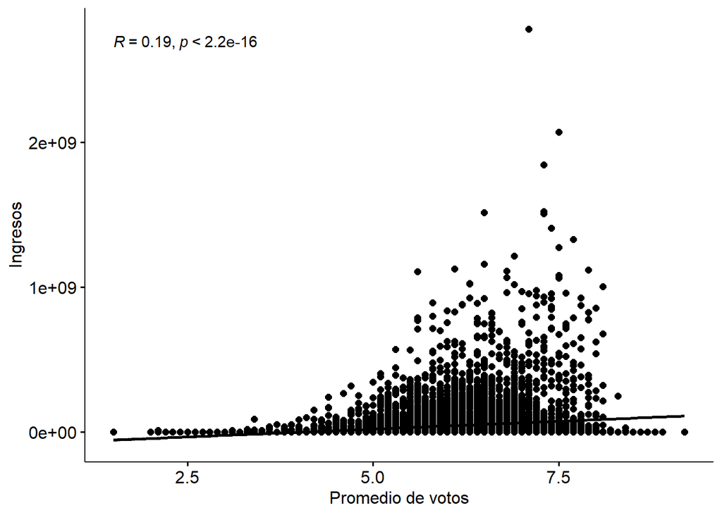

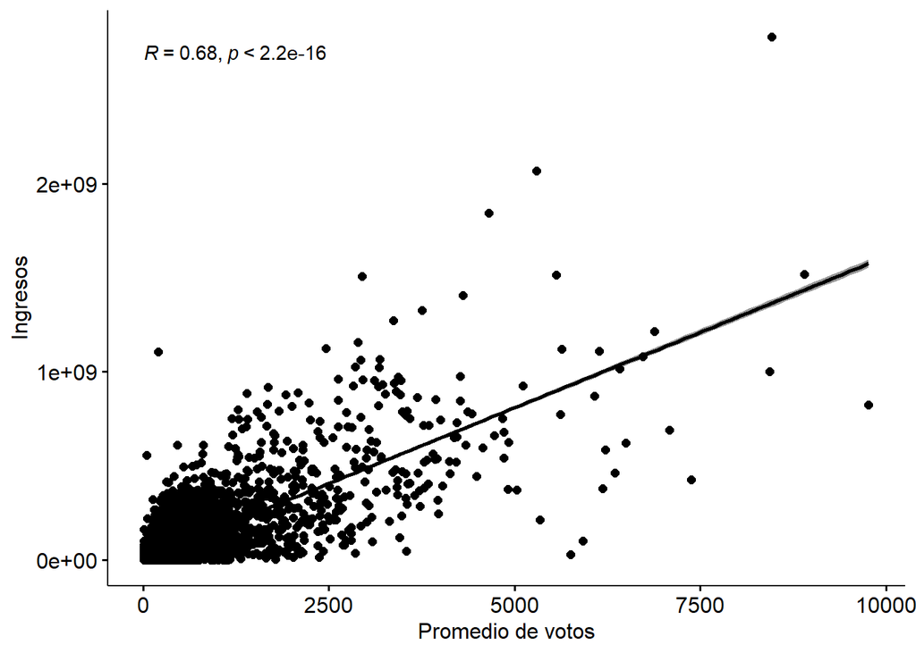

En el primer grafico de dispercion podemos notar que hay una correlacion muy baja(0.19) entre los ingresos y el promedio de votos. Por otro lado podemos ver el grafico que le sigue y tenemos una correlacion considerable de 0.68 entre los ingresos y la cantidad de votos, demostrando que a mayores vistas, mayor ingreso.

```
- ¿A qué género principal pertenecen las películas más largas?
```

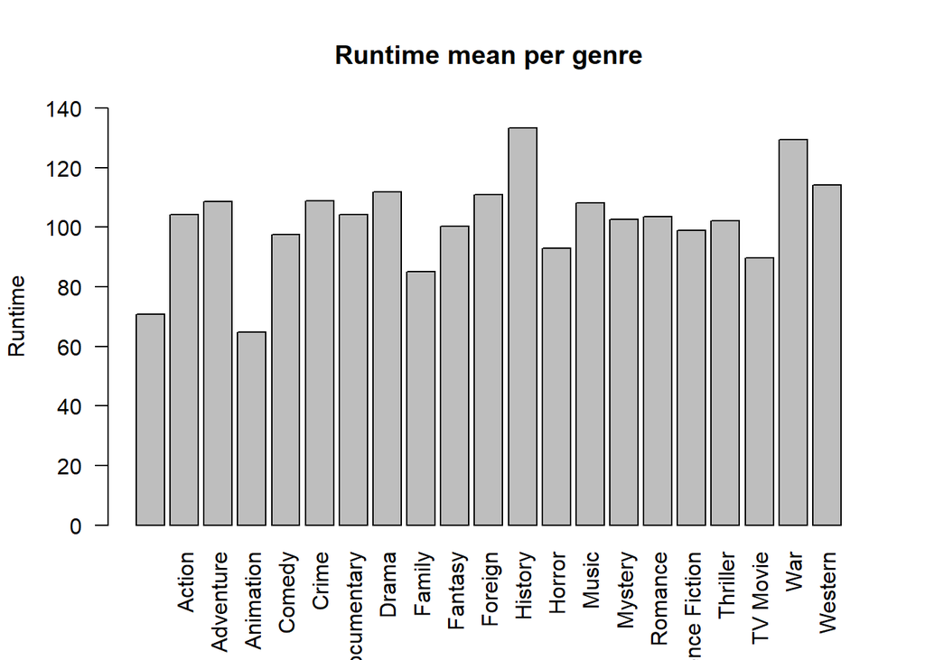

El genero pincipal al que pertenecen las peliculas mas extensas son las peliculas de historia, seguido de las peliculas de guerra como se muestra en el grafico de “Runtime mean per genre”